# Time Series Analysis for Banks

### Team 8:

Ronald Wallace G (20BDA10)

Rishab Sarkar (20BDA26)

Tanya Ranjan (20BDA32)

Gunam Ramya Sri (20BDA33)

Parvathy Charuroopa (20BDA38)

Bharath Sakthivel(20BDA59)

```r
# libraries in use:
library(tidyverse)
library(stringr)
library(dplyr)
library(tidyr)
library(tibble)
library(forecast)
library(tseries)
library(lubridate)
```

```r
library(ggplot2)
library(lmtest)
```

## Data attaching and pre-processing

```r
df_csv <- read.csv("train.csv", header = TRUE, sep = ',') %>%
  mutate(application_date = as.Date(application_date, "%d-%m-%Y")) %>%
  as_tibble()
head(df_csv)
```

```
## # A tibble: 6 x 6
##   application_date segment branch_id state       zone  no_of_applicants
##   <date>             <int>     <int> <chr>       <chr>            <int>
## 1 2017-04-01             1         1 WEST BENGAL EAST                40
## 2 2017-04-01             1         3 DELHI       NORTH               58
## 3 2017-04-01             1         5 KARNATAKA   SOUTH               10
## 4 2017-04-01             1         7 WEST BENGAL EAST                 2
## 5 2017-04-01             1         8 WEST BENGAL EAST                13
## 6 2017-04-01             1         9 WEST BENGAL EAST                11
```

##### **Checking missing values**

```r
# check for null values
for (x in c(colnames(df_csv)))
  {
    print(paste(x,"-->",sum(is.na(df_csv[x]))))
  }
```

```
## [1] "application_date --> 2970"
## [1] "segment --> 2970"
## [1] "branch_id --> 15994"
## [1] "state --> 0"
## [1] "zone --> 0"
## [1] "no_of_applicants --> 2970"
```

###### **Insights:**

The columns do seem to have missing values

State and Zone have missing values as well, as they are categorical type cols, they are being treated as class levels instead of null values.

```r
# removing the null valued data.
print(paste('orginal',dim(df_csv)))
```

```
## [1] "orginal 80402" "orginal 6"
```

```r
rectified_df_csv = na.omit(df_csv)
print(paste('rectified',dim(rectified_df_csv)))
```

```
## [1] "rectified 64408" "rectified 6"
```

##### **Converting it into a tsibble object**

```r
# as all the cols have multiple occurrences of the values, we need to create a seperate index var.
index <- c(1:nrow(rectified_df_csv))
rectified_df_csv['index'] <- index
df_tsibble <- rectified_df_csv %>% tsibble::as_tsibble(index = index)
head(df_tsibble)
```

```
## # A tsibble: 6 x 7 [1]
##   application_date segment branch_id state       zone  no_of_applicants index
##   <date>             <int>     <int> <chr>       <chr>            <int> <int>
## 1 2017-04-01             1         1 WEST BENGAL EAST                40     1
## 2 2017-04-01             1         3 DELHI       NORTH               58     2
## 3 2017-04-01             1         5 KARNATAKA   SOUTH               10     3
## 4 2017-04-01             1         7 WEST BENGAL EAST                 2     4
## 5 2017-04-01             1         8 WEST BENGAL EAST                13     5
## 6 2017-04-01             1         9 WEST BENGAL EAST                11     6
```

## EDA

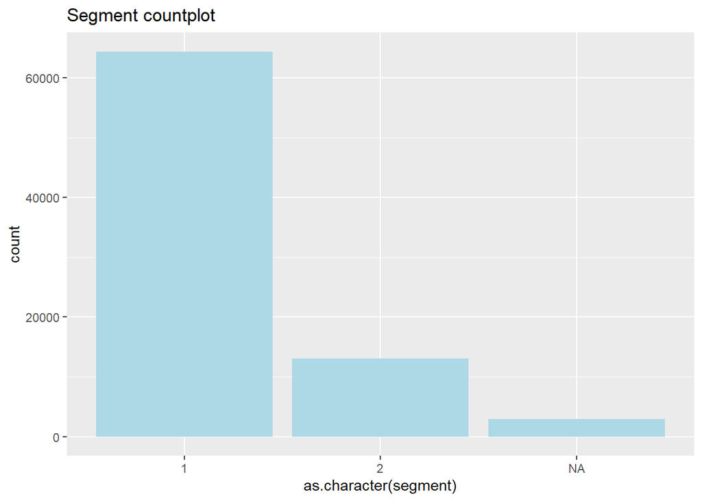

```r
# 1. segment countplot
ggplot(data = df_csv, aes(x= as.character(segment)))+
  geom_bar(fill = 'light blue')+
  ggtitle('Segment countplot')
```

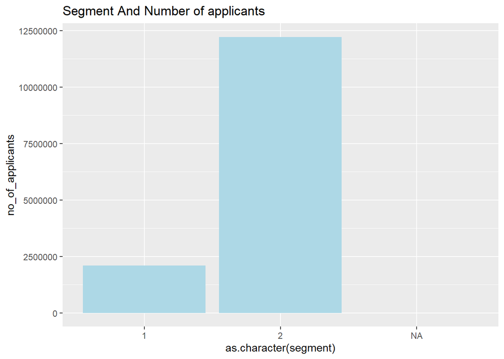

```r
# 2. segment and number of applications

ggplot(df_csv, aes(x= as.character(segment),
y = no_of_applicants))+
geom_bar(stat = 'identity',
fill = 'light blue')+
ggtitle('Segment And Number of applicants')
```

###### **Insights:**

There are more records for Segment 1

There are more number of applicants for the Segment 2.

There are some Nan values present

```r
df_csv$year <- as.numeric(format(df_csv$application_date, "%Y"))
```

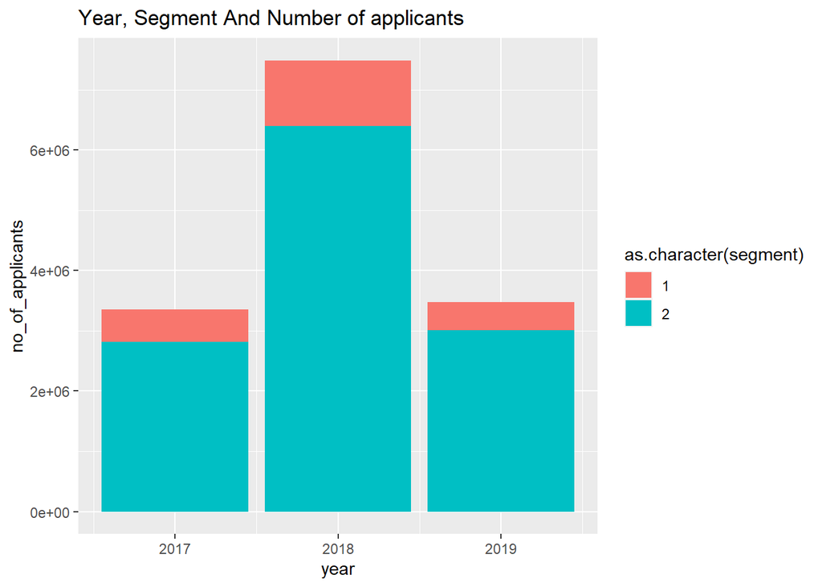

```r
# 3. Year segment and no_of_app
ggplot(df_csv, aes(x= year,
                   y = no_of_applicants,
                   fill = as.character(segment)))+
  geom_bar(stat = 'identity',
           position = 'stack')+
  ggtitle('Year, Segment And Number of applicants')
```

###### **Insights:**

Year 2018 has the highest number of applicants

Maximum applications from each segment belong to 2018

2019 has a good number of applicants considering that it only has data for half year

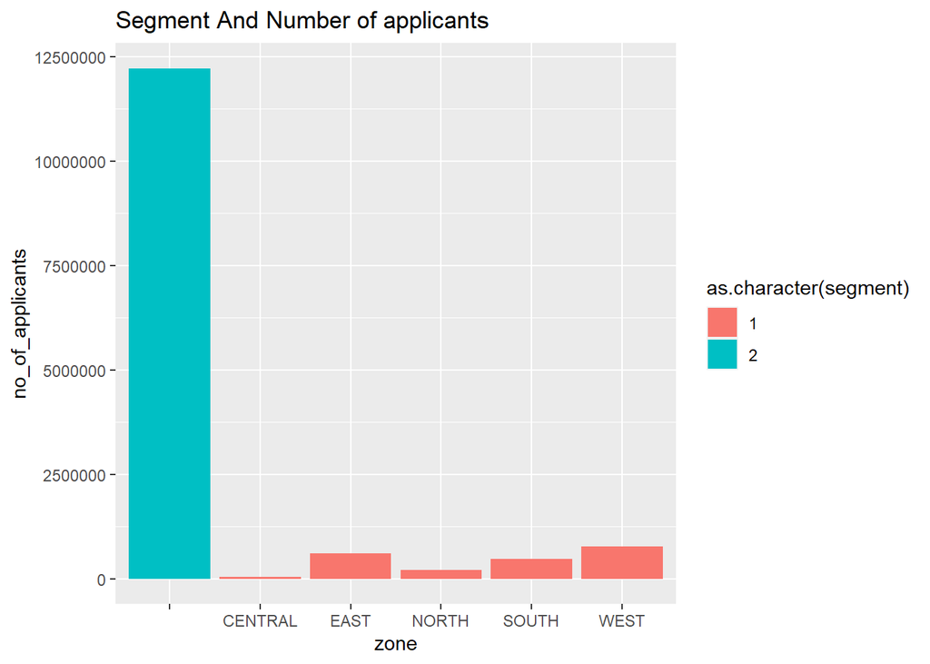

```r
# 4. plotting the number of applicants based on the zone
ggplot(df_csv, aes(x= zone,
                   y = no_of_applicants,
                   fill = as.character(segment)))+
  geom_bar(stat = 'identity',
           position = 'stack')+
  ggtitle('Segment And Number of applicants')
```